# 25_component_analysis_matrix_factorization

### [Decomposing Signals / Matrix Factorization](https://scikit-learn.org/stable/modules/decomposition.html)

### [PCA (Principal Component Analysis)](https://scikit-learn.org/stable/modules/generated/sklearn.decomposition.PCA.html#sklearn.decomposition.PCA)

- A linear dimensionality reduction technique which uses [singular value decomposition (SVD)](https://en.wikipedia.org/wiki/Singular_value_decomposition) to project a dataset to a *lower dimensional space*.
- The `fit` method learns $n$ components.
- PCA centers, but *does not scale*, inputs before applying SVD.
- `whiten=True` enables projecting the data onto the singular space while *scaling each component to unit variance*.
- Uses **LAPACK** to calculate the full SVD, or *Halko etc 2009* to find a *randomized truncated SVD*. The choice depends on the input data shape & #components to extract.

```python
import numpy as np
from sklearn.decomposition import PCA
X = np.array([[-1, -1], [-2, -1], [-3, -2],
              [ 1,  1], [ 2,  1], [ 3,  2]])

pca  = PCA(n_components=2).fit(X)
pca2 = PCA(n_components=2, svd_solver='full').fit(X)
pca3 = PCA(n_components=1, svd_solver='arpack').fit(X)

print(pca.explained_variance_ratio_)
print(pca.singular_values_)

print(pca2.explained_variance_ratio_)
print(pca2.singular_values_)

print(pca3.explained_variance_ratio_)
print(pca3.singular_values_)
```

```
[0.99244289 0.00755711]
[6.30061232 0.54980396]
[0.99244289 0.00755711]
[6.30061232 0.54980396]
[0.99244289]
[6.30061232]
```

### [Probabilistic PCA vs Factor Analysis](https://scikit-learn.org/stable/auto_examples/decomposition/plot_pca_vs_fa_model_selection.html)

- Compare PCA & FA with cross-validation on low-rank data that is corrupted with *homoscedastic noise* (noise variance is the same for each feature) or *heteroscedastic noise* (noise variance is different for each feature).
- 2nd step: compare the model likelihood to the likelihoods obtained from shrinkage covariance estimators.

```python
import numpy as np
import matplotlib.pyplot as plt
from scipy import linalg
from sklearn.decomposition import PCA, FactorAnalysis as FA
from sklearn.covariance import ShrunkCovariance as SC, LedoitWolf as LW
from sklearn.model_selection import cross_val_score as CVscore
from sklearn.model_selection import GridSearchCV
```

```python
n_samples, n_features, rank, sigma = 1000, 50, 10, 1.0
rng = np.random.RandomState(42)

U, _, _ = linalg.svd(rng.randn(n_features,
                               n_features))
X = np.dot(rng.randn(n_samples, rank),
           U[:, :rank].T)

# Adding homoscedastic & heteroscedastic noise
sigmas = sigma * rng.rand(n_features) + sigma / 2.

X_homo   = X + sigma * rng.randn(n_samples, n_features)
X_hetero = X + sigmas* rng.randn(n_samples, n_features)
```

```python
n_components = np.arange(0, n_features, 5)  # options for n_components

def compute_scores(X):
    pca = PCA(svd_solver='full')
    fa  = FA()
    pca_scores, fa_scores = [], []

    for n in n_components:
        pca.n_components = n
        fa.n_components = n
        pca_scores.append(np.mean(CVscore(pca, X)))
        fa_scores.append(np.mean( CVscore(fa,  X)))
    return pca_scores, fa_scores

def shrunk_cov_score(X):
    shrinkages = np.logspace(-2, 0, 30)
    cv = GridSearchCV(SC(), {'shrinkage': shrinkages})
    return np.mean(CVscore(cv.fit(X).best_estimator_, X))

def lw_score(X):
    return np.mean(CVscore(LW(), X))
```

```
best n_components by PCA CV = 10
best n_components by FactorAnalysis CV = 10
best n_components by PCA MLE = 10
best n_components by PCA CV = 45
best n_components by FactorAnalysis CV = 10
best n_components by PCA MLE = 39
```

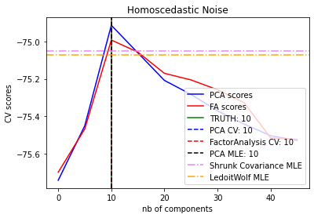

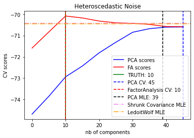

```python
for X, title in [(X_homo, 'Homoscedastic Noise'),
                 (X_hetero, 'Heteroscedastic Noise')]:

    pca_scores, fa_scores = compute_scores(X)
    n_components_pca      = n_components[np.argmax(pca_scores)]
    n_components_fa       = n_components[np.argmax(fa_scores)]
    pca                   = PCA(svd_solver='full',
                                n_components='mle').fit(X)
    n_components_pca_mle  = pca.n_components_

    print("best n_components by PCA CV = %d" %
          n_components_pca)
    print("best n_components by FactorAnalysis CV = %d" %
          n_components_fa)
    print("best n_components by PCA MLE = %d" %
          n_components_pca_mle)

    plt.figure()
    plt.plot(n_components, pca_scores, 'b', label='PCA scores')
    plt.plot(n_components,  fa_scores, 'r', label='FA scores')

    plt.axvline(rank, color='g', label='TRUTH: %d' %
                rank, linestyle='-')
    plt.axvline(n_components_pca, color='b',
                label='PCA CV: %d' %
                n_components_pca, linestyle='--')
    plt.axvline(n_components_fa, color='r',
                label='FactorAnalysis CV: %d' %
                n_components_fa,
                linestyle='--')
    plt.axvline(n_components_pca_mle, color='k',
                label='PCA MLE: %d' %
                n_components_pca_mle, linestyle='--')

    # compare with other covariance estimators
    plt.axhline(shrunk_cov_score(X), color='violet',
                label='Shrunk Covariance MLE', linestyle='-.')
    plt.axhline(lw_score(X), color='orange',
                label='LedoitWolf MLE' % n_components_pca_mle, linestyle='-.')

    plt.xlabel('nb of components')
    plt.ylabel('CV scores')
    plt.legend(loc='lower right')
    plt.title(title)
```

### [Example: PCA vs LDA, Iris dataset](https://scikit-learn.org/stable/auto_examples/decomposition/plot_pca_vs_lda.html)

- PCA finds the combination of features containing the most variance *between the samples*.
- LDA finds the attributes containing the most variance *between classes*. LDA is a supervised method, therefore using known class labels.

```python
import matplotlib.pyplot as plt

from sklearn import datasets
from sklearn.decomposition import PCA
from sklearn.discriminant_analysis import LinearDiscriminantAnalysis as LDA
```

```python
iris  = datasets.load_iris()
X,y   = iris.data, iris.target
names = iris.target_names
pca   = PCA(n_components=2)
lda   = LDA(n_components=2)
X_r   = pca.fit(X).transform(X)
X_r2  = lda.fit(X, y).transform(X)

print('explained variance ratio (1st two components): %s'
      % str(pca.explained_variance_ratio_))
```

```
explained variance ratio (1st two components): [0.92461872 0.05306648]
```

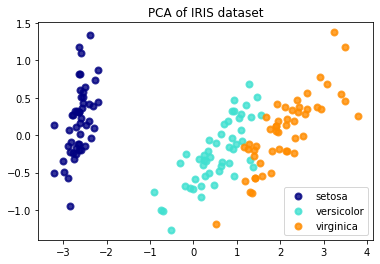

```python
colors = ['navy', 'turquoise', 'darkorange']
lw = 2

for color, i, name in zip(colors, [0, 1, 2], names):
    plt.scatter(X_r[y == i, 0],
                X_r[y == i, 1],
                color=color, alpha=.8, lw=lw,
                label=name)
plt.legend(loc='best', shadow=False, scatterpoints=1)
plt.title('PCA of IRIS dataset')
```

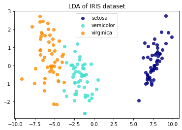

```python
for color, i, name in zip(colors, [0, 1, 2], names):
    plt.scatter(X_r2[y == i, 0],
                X_r2[y == i, 1], alpha=.8, color=color,
                label=name)
plt.legend(loc='best', shadow=False, scatterpoints=1)
plt.title('LDA of IRIS dataset')
```

### [Incremental PCA](https://scikit-learn.org/stable/modules/generated/sklearn.decomposition.IncrementalPCA.html#sklearn.decomposition.IncrementalPCA)

- Standard PCA only supports batch processing - the entire data must be in main memory.
- Incremental PCA enables *out-of-core partial computation* which can closely match PCA performance.
- `partial_fit` uses subsets of data fetched sequentially from disk or a network.
- `numpy.memmap` also enables calling the `fit` method on sparse matrices or a memory mapped file.
- Stores *estimates* of component & noise variances, and uses them to update `explained_variance_ration` incrementally.
- Memory usage depends on #samples/batch.

### [Example, Incremental PCA, Iris](https://scikit-learn.org/stable/auto_examples/decomposition/plot_incremental_pca.html)

```python
import numpy as np
import matplotlib.pyplot as plt
from sklearn.datasets import load_iris
from sklearn.decomposition import PCA, IncrementalPCA as IPCA
```

```python
iris   = load_iris()
X,y,n  = iris.data, iris.target, 2
ipca   = IPCA(n_components=n, batch_size=10)
pca    =  PCA(n_components=n)

X_ipca = ipca.fit_transform(X)
X_pca = pca.fit_transform(X)
```

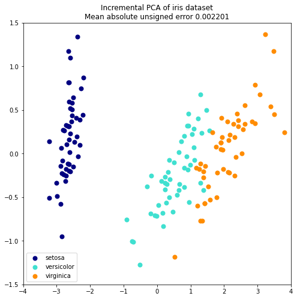

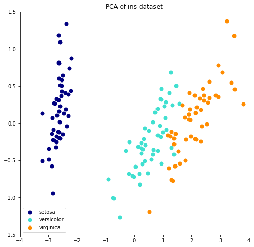

```python
colors = ['navy', 'turquoise', 'darkorange']

for X_transformed, title in [(X_ipca, "Incremental PCA"), (X_pca, "PCA")]:
    plt.figure(figsize=(8, 8))
    for color, i, name in zip(colors, [0, 1, 2],
                                     iris.target_names):
        plt.scatter(X_transformed[y == i, 0],
                    X_transformed[y == i, 1],
                    color=color, lw=2,
                    label=name)

    if "Incremental" in title:
        err = np.abs(np.abs(X_pca) - np.abs(X_ipca)).mean()
        plt.title(title + " of iris dataset\nMean absolute unsigned error "
                  "%.6f" % err)
    else:
        plt.title(title + " of iris dataset")
    plt.legend(loc="best", shadow=False, scatterpoints=1)
    plt.axis([-4, 4, -1.5, 1.5])
```

### [PCA with Randomized SVD](https://scikit-learn.org/stable/modules/generated/sklearn.decomposition.PCA.html#sklearn.decomposition.PCA)

- Use case: projecting data to a low-D space *while preserving most of the variance*. This is done by dropping the singular vector of components associated with lower singular values.
- Example: 64x64 pixel gray-level pix (for face recognition) has dimensionality = 4096 (which will make SVM training very slow). Since most human faces look somewhat alike, it makes sense to use PCA to project down to ~200 dimensions.
- In other words: if we're going to drop most of the vectors, it's more efficient to limit the computation to an approximation of the vectors.
- accomplished with `svd_solver="randomized"`.
- The memory footprint is much smaller than that of exact PCA: $2 \cdot n_{\max} \cdot n_{\mathrm{components}}$ vs $n_{\max} \cdot n_{\min}$.

### [PCA with Sparse Data](https://scikit-learn.org/stable/modules/generated/sklearn.decomposition.SparsePCA.html#sklearn.decomposition.SparsePCA)

- The $l1$ norm also protects components from noise when few training samples are available. It can be controlled via `alpha`. (Small values = gentle regularization; large values shrink many coefficients to zero.)

```python
import numpy as np
from sklearn.datasets import make_friedman1
from sklearn.decomposition import SparsePCA

X, _        = make_friedman1(n_samples=200, n_features=30, random_state=0)
transformer = SparsePCA(n_components=5,
                        random_state=0).fit(X)

X_transformed = transformer.transform(X)
print(X_transformed.shape)
print(np.mean(transformer.components_ == 0))
```

```
(200, 5)
0.9666666666666667
```

### [Example: face recognition with eigenfaces & SVMs](https://scikit-learn.org/stable/auto_examples/applications/plot_face_recognition.html#sphx-glr-auto-examples-applications-plot-face-recognition-py)

- Using "labeled faces in the wild" (LFW) dataset.

```python
from time import time
import logging
import matplotlib.pyplot as plt
from sklearn.model_selection import train_test_split as TTS
from sklearn.model_selection import GridSearchCV
from sklearn.datasets import fetch_lfw_people
from sklearn.metrics import classification_report as CR
from sklearn.metrics import confusion_matrix as CM
from sklearn.decomposition import PCA
from sklearn.svm import SVC
```

```python
lfw_people = fetch_lfw_people(min_faces_per_person=70, resize=0.4)

n_samples, h, w = lfw_people.images.shape
X               = lfw_people.data
n_features      = X.shape[1]
y               = lfw_people.target
target_names    = lfw_people.target_names
n_classes       = target_names.shape[0]

print("Total dataset size:")
print("n_samples: %d" % n_samples)
print("n_features: %d" % n_features)
print("n_classes: %d" % n_classes)
```

```
Total dataset size:
n_samples: 1288
n_features: 1850
n_classes: 7
```

```python
X_train, X_test, y_train, y_test = TTS(
    X, y, test_size=0.25, random_state=42)

n_components = 150
t0 = time()
pca = PCA(n_components=n_components,
          svd_solver='randomized',
          whiten=True).fit(X_train)
print("PCA fit done in %0.3fs" % (time() - t0))

eigenfaces = pca.components_.reshape((n_components, h, w))

t0 = time()
X_train_pca = pca.transform(X_train)
X_test_pca = pca.transform(X_test)
print("PCA transform done in %0.3fs" % (time() - t0))

t0 = time()
param_grid = {'C':     [1e3,    5e3,    1e4,   5e4,   1e5],
              'gamma': [0.0001, 0.0005, 0.001, 0.005, 0.01, 0.1], }

clf = GridSearchCV(
    SVC(kernel='rbf', class_weight='balanced'),
    param_grid).fit(X_train_pca,
                   y_train)

print("CV done in %0.3fs" % (time() - t0))
print("Best estimator:", clf.best_estimator_)
```

```
PCA fit done in 0.706s
PCA transform done in 0.044s
CV done in 11.058s
Best estimator: SVC(C=1000.0, class_weight='balanced', gamma=0.005)
```

```python
t0 = time()
y_pred = clf.predict(X_test_pca)
print("Prediction quality on test data: done in %0.3fs" % (time() - t0))
print(CR(y_test, y_pred, target_names=target_names))
print(CM(y_test, y_pred, labels=range(n_classes)))
```

```
Prediction quality on test data: done in 0.038s
                   precision    recall  f1-score   support

     Ariel Sharon       0.80      0.62      0.70        13
     Colin Powell       0.82      0.88      0.85        60
  Donald Rumsfeld       0.86      0.67      0.75        27
    George W Bush       0.85      0.98      0.91       146
Gerhard Schroeder       0.95      0.80      0.87        25
      Hugo Chavez       1.00      0.53      0.70        15
       Tony Blair       1.00      0.81      0.89        36

         accuracy                           0.87       322
        macro avg       0.90      0.75      0.81       322
     weighted avg       0.87      0.87      0.86       322

[[  8   2   0   3   0   0   0]
 [  1  53   1   5   0   0   0]
 [  1   1  18   7   0   0   0]
 [  0   3   0 143   0   0   0]
 [  0   1   0   4  20   0   0]
 [  0   3   0   3   1   8   0]
 [  0   2   2   3   0   0  29]]
```

```python
def plot_gallery(images, titles, h, w, n_row=3, n_col=4):
    plt.figure(figsize=(1.8*n_col, 2.4*n_row))
    plt.subplots_adjust(bottom=0, left=.01, right=.99, top=.90, hspace=.35)

    for i in range(n_row*n_col):
        plt.subplot(n_row, n_col, i+1)
        plt.imshow(images[i].reshape((h, w)), cmap=plt.cm.gray)
        plt.title(titles[i], size=12)
        plt.xticks(())
        plt.yticks(())

def title(y_pred, y_test, target_names, i):
    pred_name = target_names[y_pred[i]].rsplit(' ', 1)[-1]
    true_name = target_names[y_test[i]].rsplit(' ', 1)[-1]
    return 'predicted: %s\ntrue:      %s' % (pred_name, true_name)
```

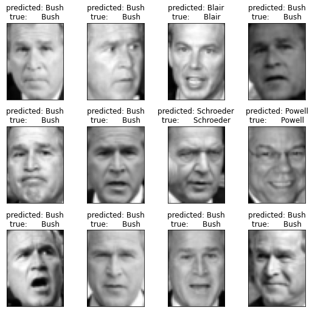

```python
# plots predictions on test set
prediction_titles = [title(y_pred, y_test, target_names, i)
                     for i in range(y_pred.shape[0])]

plot_gallery(X_test, prediction_titles, h, w)
```

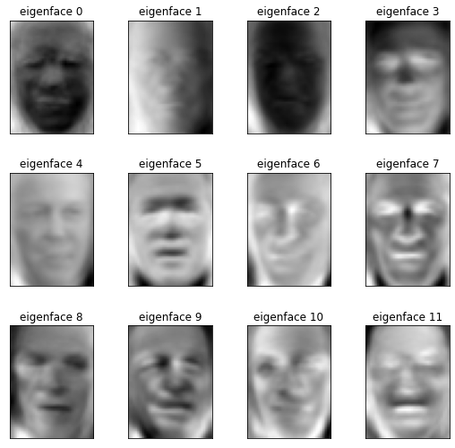

```python
# plot most significative eigenfaces
eigenface_titles = ["eigenface %d" % i for i in range(eigenfaces.shape[0])]
plot_gallery(eigenfaces, eigenface_titles, h, w)
```

### [Example: Dimension Reduction method comparison](https://scikit-learn.org/stable/auto_examples/decomposition/plot_faces_decomposition.html#sphx-glr-auto-examples-decomposition-plot-faces-decomposition-py)

- Using the Olivetti faces dataset
- Algorithm options:
  - **PCA / Randomized SVD**
  - **Factor Analysis**
  - **NMF**
  - **Fast ICA**
  - **PCA / Sparse Data / MiniBatch**
  - **Dictionary Learning / Multiple Variants**
  - **KMeans / MiniBatch**

```python
import logging
from time import time
from numpy.random import RandomState as RS
import matplotlib.pyplot as plt
from sklearn.datasets import fetch_olivetti_faces
from sklearn.cluster import MiniBatchKMeans
from sklearn import decomposition
```

```python
n_row, n_col = 2, 3
n_components = n_row*n_col
image_shape  = (64, 64)
rng          = RS(0)
faces, _     = fetch_olivetti_faces(return_X_y=True, shuffle=True,
                                random_state=rng)
# global then local centering
n_samples, n_features = faces.shape
faces_centered        = faces - faces.mean(axis=0)
faces_centered       -= faces_centered.mean(axis=1).reshape(n_samples, -1)
print("Dataset: %d faces" % n_samples)
```

```
Dataset: 400 faces
```

```python
def plot_gallery(title, images, n_col=n_col, n_row=n_row, cmap=plt.cm.gray):
    plt.figure(figsize=(2.0*n_col, 2.26*n_row))
    plt.suptitle(title, size=16)
    for i, comp in enumerate(images):
        plt.subplot(n_row, n_col, i+1)
        vmax = max(comp.max(), -comp.min())
        plt.imshow(comp.reshape(image_shape), cmap=cmap,
                   interpolation='nearest',
                   vmin=-vmax, vmax=vmax)
        plt.xticks(())
        plt.yticks(())
    plt.subplots_adjust(0.01, 0.05, 0.99, 0.93, 0.04, 0.)
```

```python
estimators = [
    ('Eigenfaces - PCA/randomized SVD',
     decomposition.PCA(n_components=n_components,
                       svd_solver='randomized',
                       whiten=True),
     True),

    ('NMF',
     decomposition.NMF(n_components=n_components,
                       init='nndsvda',
                       tol=5e-3),
     False),

    ('FastICA',
     decomposition.FastICA(n_components=n_components,
                           whiten=True),
     True),

    ('MiniBatchSparsePCA',
     decomposition.MiniBatchSparsePCA(n_components=n_components,
                                      alpha=0.8,
                                      n_iter=100,
                                      batch_size=3,
                                      random_state=rng),
     True),

    ('MiniBatchDictionaryLearning',
        decomposition.MiniBatchDictionaryLearning(n_components=15,
                                                  alpha=0.1,
                                                  n_iter=50,
                                                  batch_size=3,
                                                  random_state=rng),
     True),

    ('Cluster centers - MiniBatchKMeans',
        MiniBatchKMeans(n_clusters=n_components,
                        tol=1e-3,
                        batch_size=20,
                        max_iter=50,
                        random_state=rng),
     True),

    ('Factor Analysis',
     decomposition.FactorAnalysis(n_components=n_components,
                                  max_iter=20),
     True),
]
```

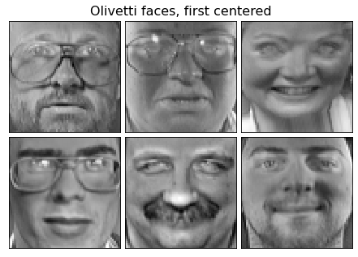

```python
plot_gallery("Olivetti faces, first centered",
             faces_centered[:n_components])
```

- Plot images showing pixelwise variance using an estimator's `noise_variance` attribute.
- The *Eigenfaces* estimator also has a `noise_variance_` (mean of pixelwise variance) - skip it.

```
done in 0.388s
done in 0.198s
done in 0.135s
done in 0.722s
done in 1.407s
done in 0.251s
done in 0.533s
```

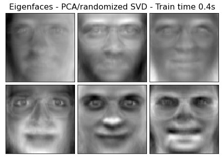

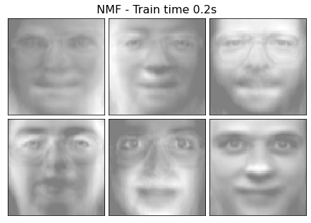

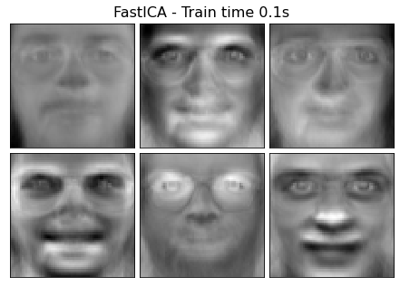

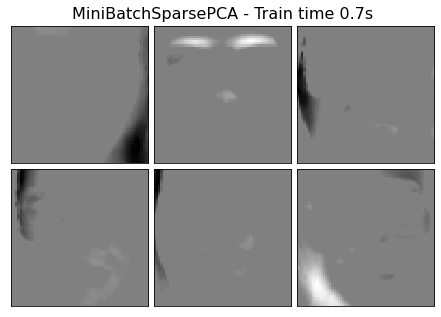

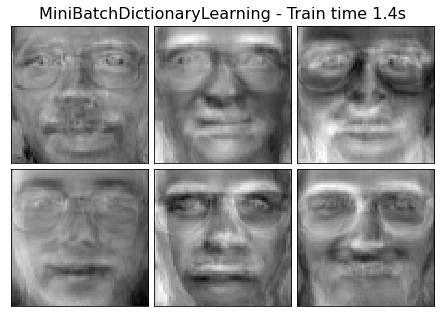

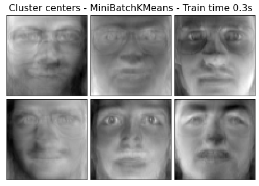

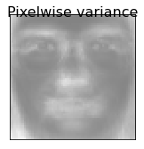

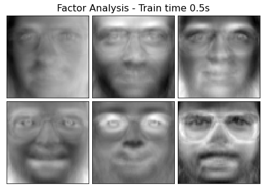

```python
for name, estimator, center in estimators:
    t0 = time()
    data = faces
    if center:
        data = faces_centered
    estimator.fit(data)
    train_time = time()-t0
    print("done in %0.3fs" % train_time)

    if hasattr(estimator, 'cluster_centers_'):
        components_ = estimator.cluster_centers_
    else:
        components_ = estimator.components_

    if (hasattr(estimator, 'noise_variance_') and
            estimator.noise_variance_.ndim > 0):  # Skip the Eigenfaces case
        plot_gallery("Pixelwise variance",
                     estimator.noise_variance_.reshape(1, -1),
                     n_col=1, n_row=1)
    plot_gallery('%s - Train time %.1fs' % (name, train_time),
                 components_[:n_components])
```

```python
from sklearn.decomposition import MiniBatchDictionaryLearning as MBDL

# dictionary learning with various positivity constraints
estimators = [
    ('Dictionary learning (DL)',
        MBDL(n_components=15,
             alpha=0.1, n_iter=50, batch_size=3,
             random_state=rng), True),

    ('DL - positive dictionary',
        MBDL(n_components=15,
             alpha=0.1, n_iter=50, batch_size=3,
             random_state=rng, positive_dict=True), True),

    ('DL - positive code',
        MBDL(n_components=15,
             alpha=0.1, n_iter=50, batch_size=3,
             random_state=rng, positive_code=True, fit_algorithm='cd'), True),

    ('DL - positive dictionary & code',
        MBDL(n_components=15,
             alpha=0.1, n_iter=50, batch_size=3,
             random_state=rng, positive_code=True, fit_algorithm='cd',
             positive_dict=True), True),
]
```

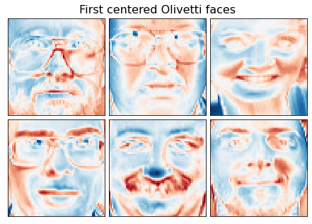

```python
plot_gallery("First centered Olivetti faces",
             faces_centered[:n_components],
             cmap=plt.cm.RdBu)
```

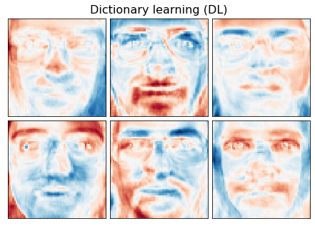

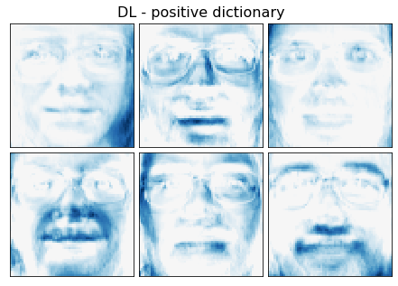

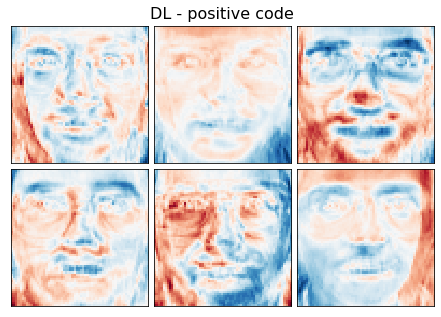

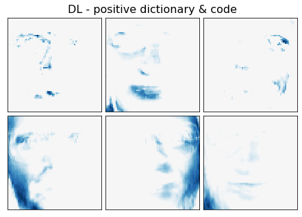

```python
for name, estimator, center in estimators:
    data = faces
    if center:
        data = faces_centered
    estimator.fit(data)
    components_ = estimator.components_
    plot_gallery(name, components_[:n_components], cmap=plt.cm.RdBu)
```

### Non-Linear Dimensionality Reduction - [Kernel PCA](https://scikit-learn.org/stable/modules/generated/sklearn.decomposition.KernelPCA.html#sklearn.decomposition.KernelPCA)

- Extends PCA with **kernels**:
  - "linear", "poly", "rbf", "sigmoid", "cosine", "precomputed"
  - "linear" = default

```python
import numpy as np
import matplotlib.pyplot as plt
from sklearn.decomposition import PCA, KernelPCA
from sklearn.datasets import make_circles
```

```python
np.random.seed(0)
X, y   = make_circles(n_samples=400, factor=.3, noise=.05)
kpca   = KernelPCA(kernel="rbf", fit_inverse_transform=True, gamma=10)
X_kpca = kpca.fit_transform(X)
X_back = kpca.inverse_transform(X_kpca)
pca    = PCA()
X_pca  = pca.fit_transform(X)
```

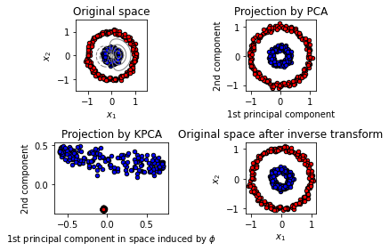

```python
plt.figure()
plt.subplot(2, 2, 1, aspect='equal')
plt.title("Original space")
reds = y == 0
blues = y == 1

plt.scatter(X[reds, 0], X[reds, 1], c="red",    s=20, edgecolor='k')
plt.scatter(X[blues, 0], X[blues, 1], c="blue", s=20, edgecolor='k')
plt.xlabel("$x_1$")
plt.ylabel("$x_2$")

X1, X2 = np.meshgrid(np.linspace(-1.5, 1.5, 50),
                     np.linspace(-1.5, 1.5, 50))
X_grid = np.array([np.ravel(X1),
                   np.ravel(X2)]).T

# projection on the first principal component (in the phi space)
Z_grid = kpca.transform(X_grid)[:, 0].reshape(X1.shape)
plt.contour(X1, X2, Z_grid,
            colors='grey', linewidths=1, origin='lower')

plt.subplot(2, 2, 2, aspect='equal')
plt.scatter(X_pca[reds,  0], X_pca[reds,  1], c="red",  s=20, edgecolor='k')
plt.scatter(X_pca[blues, 0], X_pca[blues, 1], c="blue", s=20, edgecolor='k')
plt.title("Projection by PCA")
plt.xlabel("1st principal component")
plt.ylabel("2nd component")

plt.subplot(2, 2, 3, aspect='equal')
plt.scatter(X_kpca[reds,  0], X_kpca[reds,  1], c="red",  s=20, edgecolor='k')
plt.scatter(X_kpca[blues, 0], X_kpca[blues, 1], c="blue", s=20, edgecolor='k')
plt.title("Projection by KPCA")
plt.xlabel(r"1st principal component in space induced by $\phi$")
plt.ylabel("2nd component")

plt.subplot(2, 2, 4, aspect='equal')
plt.scatter(X_back[reds,  0], X_back[reds,  1], c="red",  s=20, edgecolor='k')
plt.scatter(X_back[blues, 0], X_back[blues, 1], c="blue", s=20, edgecolor='k')
plt.title("Original space after inverse transform")
plt.xlabel("$x_1$")
plt.ylabel("$x_2$")

plt.tight_layout()
```

### [Truncated SVD](https://scikit-learn.org/stable/modules/generated/sklearn.decomposition.TruncatedSVD.html#sklearn.decomposition.TruncatedSVD)

- Only computes the $k$ largest singular values. $k$ is a given parameter.
- Also known as **[latent semantic analysis (LSA)](https://nlp.stanford.edu/IR-book/pdf/18lsi.pdf)** when applied to *term-document matrices* (usually built using CountVectorizer or [TfIdfVectorizer](https://scikit-learn.org/stable/modules/generated/sklearn.feature_extraction.text.TfidfVectorizer.html#sklearn.feature_extraction.text.TfidfVectorizer).)
- Very similar to **PCA**, but $X$ does not need to be centered. If the column-wise (per feature) means are subtracted from $X$, then truncated SVD on the resulting matrix is equivalent to PCA. This means **Trauncated SVD** accepts `scipy.sparse` data as-is.
- Recommendeded (over raw frequency counts) when used on *tf-idf* matrices.
- Recommend using `sublinear_tf=True` & `use_idf=True` to bring the feature values closer to a Gaussian distribution.

### [Example: Document topic clustering - feature extraction method comparison](https://scikit-learn.org/stable/auto_examples/text/plot_document_clustering.html#sphx-glr-auto-examples-text-plot-document-clustering-py)

```python
from sklearn.datasets import fetch_20newsgroups
from sklearn.decomposition import TruncatedSVD
from sklearn.feature_extraction.text import TfidfVectorizer as TV
from sklearn.feature_extraction.text import HashingVectorizer as HV
from sklearn.feature_extraction.text import TfidfTransformer as TT
from sklearn.pipeline import make_pipeline
from sklearn.preprocessing import Normalizer
from sklearn import metrics
from sklearn.cluster import KMeans, MiniBatchKMeans
import logging
from optparse import OptionParser
import sys
from time import time
import numpy as np
```

```python
categories = [
    'alt.atheism',
    'talk.religion.misc',
    'comp.graphics',
    'sci.space',
]
dataset = fetch_20newsgroups(subset='all',
                             categories=categories,
                             shuffle=True, random_state=42)

print("%d documents" % len(dataset.data))
print("%d categories" % len(dataset.target_names))
```

```
3387 documents
4 categories
```

```python
labels = dataset.target
true_k = np.unique(labels).shape[0]
n_features = 10000 # default

# use hashing; use IDF
t0 = time()
hasher = HV(n_features=n_features,
            stop_words='english',
            alternate_sign=False,
            norm=None)

vectorizer_1 = make_pipeline(hasher, TT())
svd          = TruncatedSVD(n_components=100)
normalizer   = Normalizer(copy=False)
lsa          = make_pipeline(svd,normalizer)
X            = vectorizer_1.fit_transform(dataset.data)
X            = lsa.fit_transform(X)

print("done:\t %fs" % (time()-t0))
print("#samples: %d, #features: %d" % X.shape)
print("explained variance in SVD: {}%".format(
        svd.explained_variance_ratio_.sum()))
```

```
done:	 1.533583s
#samples: 3387, #features: 100
explained variance in SVD: 0.23241585380104632%
```

```python
def do_clustering(data,mini):
    if mini:
        km = MiniBatchKMeans(n_clusters=true_k,
                       init='k-means++',
                       n_init=1,
                       init_size=1000,
                       batch_size=1000,
                       verbose=False)
    else:
        km = KMeans(n_clusters=true_k,
                init='k-means++',
                max_iter=100,
                n_init=1,
                verbose=False)
    t0=time(); km.fit(data); print("time:", time()-t0)

do_clustering(X,True)
do_clustering(X,False)
```

```
time: 0.1408977508544922
time: 0.1494762897491455
```

```python
def do_metrics(data,labels,labels_):
    print("Homogeneity:\t %0.2f" %
             metrics.homogeneity_score(labels,labels_))
    print("Completeness:\t %0.2f" %
             metrics.completeness_score(labels,labels_))
    print("V-Measure:\t %0.2f" %
             metrics.v_measure_score(labels,labels_))
    print("Adj Rand Index:\t %0.2f" %
             metrics.adjusted_rand_score(labels,labels_))
    print("Silhouette Coef:\t %0.2f" %
             metrics.silhouette_score(data,labels_,sample_size=1000))

do_metrics(X,labels=labels,labels_=km.labels_)
```

```
Homogeneity:	 0.50
Completeness:	 0.50
V-Measure:	 0.50
Adj Rand Index:	 0.44
Silhouette Coef:	 0.04
```

```python
def dothis(svd,km,comps,vectorizer):
    if comps:
        original_space_centroids = svd.inverse_transform(km.cluster_centers)
        order_centroids = original_space_centroids.argsort()[:,::-1]
    else:
        order_centroids = km.cluster_centers.argsort()[:,::-1]
    terms = vectorizer.get_feature_names()
    for i in range(true_k):
        print("Cluster:\t %d" % i)
        for ind in order_centroids[i,:10]:
            print(" %s" % terms[ind])
```

### [Dictionary Learning: Sparse Coding](https://scikit-learn.org/stable/modules/generated/sklearn.decomposition.SparseCoder.html#sklearn.decomposition.SparseCoder)

- Transforms signals into a *sparse linear combination of atoms* from a fixed, precomputed dictionary. (So a `fit` method is not needed.)
- Multiple transform methods are available via `transform_method`:
  - **Orthogonal matching pursuit** (best for image reconstruction.)
  - **Least Angle Regression (LARS)**
  - **Lasso/LARS**
  - **Lasso/Coordinate Descent**
  - **Thresholding** (very fast, not very accurate.)
- `split_code` enables *separating positive & negative values* in the results. This allows the learning algorithm to assign different weights to negative loads of a specific atom.
- The *split code* for a sample has length=`2*n_components`. The first `n_components` entries are filled with the *positive part* of the vector; the remainder are filled with the *negative entries*. (But with a positive sign. The split code is thus non-negative.)

### [Example; Compare sparse coding methods](https://scikit-learn.org/stable/auto_examples/decomposition/plot_sparse_coding.html#sphx-glr-auto-examples-decomposition-plot-sparse-coding-py)

- Transform a signal as a sparse combination of [Ricker wavelets](https://en.wikipedia.org/wiki/Ricker_wavelet).
- Shows how different atom widths effect the fit quality. (Therefore dictonary learning helps.)
- Richer dictionary on the right: not larger, but heavier subsampling is needed to stay on the same order of magnitude.

```python
import numpy as np
import matplotlib.pyplot as plt
from sklearn.decomposition import SparseCoder
from sklearn.utils.fixes import np_version, parse_version
```

```python
# Discrete sub-sampled Ricker wavelet
def ricker_function(resolution, center, width):
    x = np.linspace(0, resolution-1, resolution)
    x = ((2/(np.sqrt(3*width)*np.pi**0.25))
         * (1-(x-center)**2/width**2)
         * np.exp(-(x-center)**2/(2*width**2)))
    return x

# Dictionary of Ricker wavelets
def ricker_matrix(width, resolution, n_components):
    centers = np.linspace(0, resolution-1, n_components)
    D       = np.empty((n_components, resolution))
    for i, center in enumerate(centers):
        D[i] = ricker_function(resolution, center, width)
    D /= np.sqrt(np.sum(D**2, axis=1))[:, np.newaxis]
    return D
```

```python
resolution, subsampling, width = 1024, 3, 100
n_components = resolution // subsampling

# Compute a wavelet dictionary
D_fixed = ricker_matrix(width=width,
                        resolution=resolution,
                        n_components=n_components)
D_multi = np.r_[tuple(ricker_matrix(width=w,
                                    resolution=resolution,
                                    n_components=n_components//5)
                for w in (10, 50, 100, 500, 1000))]

# Generate a signal
y                                = np.linspace(0, resolution-1, resolution)
first_quarter                    = y<resolution/4
y[first_quarter]                 = 3.
y[np.logical_not(first_quarter)] = -1.
```

```python
# title, xform_algo, xform_alpha, xform_n_nozero_coefs, color)
estimators = [('OMP',   'omp',        None, 15,   'navy'),
              ('Lasso', 'lasso_lars', 2,    None, 'turquoise'), ]
lw = 2
# Avoid FutureWarning about default value change when numpy >= 1.14
lstsq_rcond = None if np_version >= parse_version('1.14') else -1
```

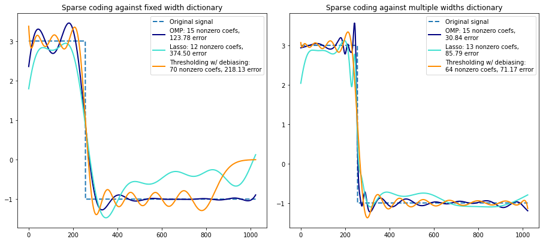

```python
plt.figure(figsize=(13,6))

for subplot, (D, title) in enumerate(zip((D_fixed, D_multi),
                                         ('fixed width',
                                          'multiple widths'))):
    plt.subplot(1, 2, subplot + 1)
    plt.title('Sparse coding against %s dictionary' % title)
    plt.plot(y, lw=lw, linestyle='--', label='Original signal')

    # Do a wavelet approximation
    for title, algo, alpha, n_nonzero, color in estimators:
        coder = SparseCoder(dictionary=D,
                            transform_n_nonzero_coefs=n_nonzero,
                            transform_alpha=alpha,
                            transform_algorithm=algo)

        x             = coder.transform(y.reshape(1, -1))
        density       = len(np.flatnonzero(x))
        x             = np.ravel(np.dot(x,D))
        squared_error = np.sum((y-x)**2)

        plt.plot(x, color=color, lw=lw,
                 label='%s: %s nonzero coefs,\n%.2f error'
                 % (title, density, squared_error))

    # Soft thresholding debiasing
    coder = SparseCoder(dictionary=D,
                        transform_algorithm='threshold',
                        transform_alpha=20)

    x = coder.transform(y.reshape(1, -1))
    _, idx = np.where(x != 0)
    x[0, idx], _, _, _ = np.linalg.lstsq(D[idx, :].T,
                                         y,
                                         rcond=lstsq_rcond)
    x = np.ravel(np.dot(x, D))
    squared_error = np.sum((y-x)**2)

    plt.plot(x,
             color='darkorange', lw=lw,
             label='Thresholding w/ debiasing:\n%d nonzero coefs, %.2f error'
             % (len(idx), squared_error))
    plt.axis('tight')
    plt.legend(shadow=False, loc='best')
plt.subplots_adjust(.04, .07, .97, .90, .09, .2)
```

### Generic [Dictionary Learning](https://scikit-learn.org/stable/modules/generated/sklearn.decomposition.DictionaryLearning.html#sklearn.decomposition.DictionaryLearning)

### [Example: Image denoising with DL](https://scikit-learn.org/stable/auto_examples/decomposition/plot_image_denoising.html#sphx-glr-auto-examples-decomposition-plot-image-denoising-py)

```python
from time import time
import matplotlib.pyplot as plt
import numpy as np
import scipy as sp
from sklearn.decomposition import MiniBatchDictionaryLearning as MBDL
from sklearn.feature_extraction.image import extract_patches_2d as EP2D
from sklearn.feature_extraction.image import reconstruct_from_patches_2d as RP2D
```

```python
try:  # SciPy >= 0.16 have face in misc
    from scipy.misc import face
    face = face(gray=True)
except ImportError:
    face = sp.face(gray=True)

# Convert from uint8 (0-255) to fp (0.0-1.0); downsample for speed
face = face / 255.
face = face[::4, ::4] + face[1::4, ::4] + face[::4, 1::4] + face[1::4, 1::4]
face /= 4.0
height, width = face.shape

# Distort the right half of the image
distorted = face.copy()
distorted[:, width // 2:] += 0.075 * np.random.randn(height, width // 2)

# Extract reference patches from the left half of the image
t0 = time()
patch_size = (7, 7)
data       = EP2D(distorted[:, :width // 2], patch_size)
data       = data.reshape(data.shape[0], -1)
data      -= np.mean(data, axis=0)
data      /= np.std(data, axis=0)
print('done: %.3fs.' % (time() - t0))
```

```
done: 0.006s.
```

```
done:	 8.665220499038696
```

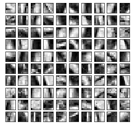

```python
t0 = time()
dico = MBDL(n_components=100,
            alpha=1,
            n_iter=500)
V = dico.fit(data).components_
print('done:\t', time()-t0)

plt.figure(figsize=(4.2, 4))
for i, comp in enumerate(V[:100]):
    plt.subplot(10, 10, i + 1)
    plt.imshow(comp.reshape(patch_size),
               cmap=plt.cm.gray_r,
               interpolation='nearest')
    plt.xticks(())
    plt.yticks(())
#plt.suptitle('Dictionary learned from face patches\n' +
#             'Train time %.1fs on %d patches' % (dt, len(data)), fontsize=16)
plt.subplots_adjust(0.08, 0.02, 0.92, 0.85, 0.08, 0.23)
```

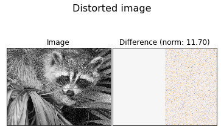

```python
# distorted image
def show_with_diff(image, reference, title):
    plt.figure(figsize=(5, 3.3))
    plt.subplot(1, 2, 1)
    plt.title('Image')
    plt.imshow(image, vmin=0, vmax=1, cmap=plt.cm.gray,
               interpolation='nearest')
    plt.xticks(())
    plt.yticks(())

    plt.subplot(1, 2, 2)
    difference = image - reference
    plt.title('Difference (norm: %.2f)' % np.sqrt(np.sum(difference ** 2)))
    plt.imshow(difference, vmin=-0.5, vmax=0.5, cmap=plt.cm.PuOr,
               interpolation='nearest')
    plt.xticks(())
    plt.yticks(())

    plt.suptitle(title, size=16)
    plt.subplots_adjust(0.02, 0.02, 0.98, 0.79, 0.02, 0.2)

show_with_diff(distorted, face, 'Distorted image')
```

```
Noisy patch extraction: done in 0.00s.
OMP
1 atom...
done in 0.92s.
OMP
2 atoms...
done in 1.66s.
LARS
5 atoms...
done in 14.27s.
Thresholding
 alpha=0.1...
done in 0.19s.
```

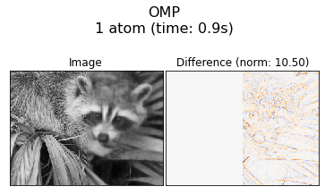

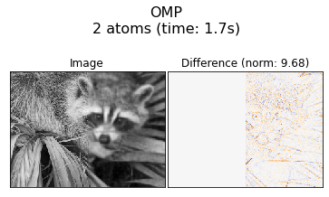

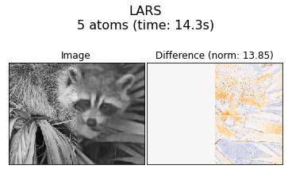

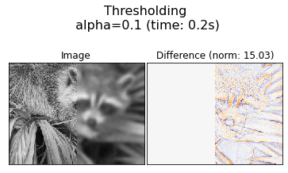

```python
t0 = time()
data      = EP2D(distorted[:, width // 2:], patch_size)
data      = data.reshape(data.shape[0], -1)
intercept = np.mean(data, axis=0)
data     -= intercept
print('Noisy patch extraction: done in %.2fs.' % (time() - t0))

transform_algorithms = [
    ('OMP\n1 atom', 'omp',    {'transform_n_nonzero_coefs': 1}),
    ('OMP\n2 atoms', 'omp',   {'transform_n_nonzero_coefs': 2}),
    ('LARS\n5 atoms', 'lars', {'transform_n_nonzero_coefs': 5}),
    ('Thresholding\n alpha=0.1', 'threshold', {'transform_alpha': .1})]

reconstructions = {}

for title, transform_algorithm, kwargs in transform_algorithms:
    print(title + '...')
    reconstructions[title] = face.copy()

    t0 = time()
    dico.set_params(transform_algorithm=transform_algorithm, **kwargs)
    code     = dico.transform(data)
    patches  = np.dot(code, V)
    patches += intercept
    patches  = patches.reshape(len(data), *patch_size)

    if transform_algorithm == 'threshold':
        patches -= patches.min()
        patches /= patches.max()

    reconstructions[title][:, width // 2:] = RP2D(patches,
                                                  (height,
                                                   width//2))
    dt = time() - t0
    print('done in %.2fs.' % dt)
    show_with_diff(reconstructions[title], face,
                   title + ' (time: %.1fs)' % dt)
```

### [Dictionary Learning (Minibatch)](https://scikit-learn.org/stable/modules/generated/sklearn.decomposition.MiniBatchDictionaryLearning.html#sklearn.decomposition.MiniBatchDictionaryLearning)

- Faster but less accurate. Better suited for large datasets.
- Divides dataset into batches & cycles between them for a specified #iterations. This implementation does not have a stopping condition.
- `partial_fit` is supported. It updates the dictionary by iterating only once on a given batch. This can be used for online learning where the complete dataset is not available from the beginning, or does not fit into main memory.

### [Example: Learn Face Image Patches](https://scikit-learn.org/stable/auto_examples/cluster/plot_dict_face_patches.html#sphx-glr-auto-examples-cluster-plot-dict-face-patches-py)

- Uses the Olivetti faces dataset.
- Good example of online (streamed) API - load one image, extract 50 random patches. Once 500 patches are accumulated from 10 images, run partial_fit on the minibatch Kmeans object.
- Some clusters are reassigned during successive calls to partial_fit, because the #patches they represent has become too low - it's better to choose a new random cluster.

```
[MiniBatchKMeans] Reassigning 11 cluster centers.
[MiniBatchKMeans] Reassigning 2 cluster centers.
done in 4.07s.
```

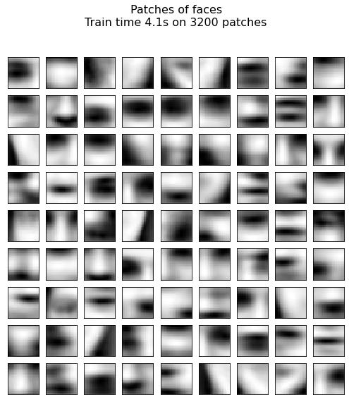

```python
import time
import matplotlib.pyplot as plt
import numpy as np
from sklearn import datasets
from sklearn.cluster import MiniBatchKMeans as MBKM
from sklearn.feature_extraction.image import extract_patches_2d as EP2D

faces = datasets.fetch_olivetti_faces()

# Learn image dictionary
rng = np.random.RandomState(0)
kmeans = MBKM(n_clusters=81, random_state=rng, verbose=True)
patch_size = (20, 20)
buffer = []
t0 = time.time()

# online learning: cycle through entire dataset 6 times
index = 0
for _ in range(6):
    for img in faces.images:
        data = EP2D(img, patch_size, max_patches=50, random_state=rng)
        data = np.reshape(data, (len(data), -1))
        buffer.append(data)
        index += 1
        if index % 10 == 0:
            data = np.concatenate(buffer, axis=0)
            data -= np.mean(data, axis=0)
            data /= np.std(data, axis=0)
            kmeans.partial_fit(data)
            buffer = []
        #if index % 100 == 0:
        #    print('Partial fit of %4i out of %i'
        #          % (index, 6 * len(faces.images)))

dt = time.time() - t0
print('done in %.2fs.' % dt)

#plt.figure(figsize=(4.2, 4))
plt.figure(figsize=(8,8))
for i, patch in enumerate(kmeans.cluster_centers_):
    plt.subplot(9, 9, i + 1)
    plt.imshow(patch.reshape(patch_size), cmap=plt.cm.gray,
               interpolation='nearest')
    plt.xticks(())
    plt.yticks(())


plt.suptitle('Patches of faces\nTrain time %.1fs on %d patches' %
             (dt, 8 * len(faces.images)), fontsize=16)
plt.subplots_adjust(0.08, 0.02, 0.92, 0.85, 0.08, 0.23)

plt.show()
```

### [Example: FA with rotation](https://scikit-learn.org/stable/auto_examples/decomposition/plot_varimax_fa.html#sphx-glr-auto-examples-decomposition-plot-varimax-fa-py)

- Using the Iris dataset.
- Matrix decomposition can *reveal latent relations* between sepal length, petal length & petal width.
- Applying rotations to the resulting components doesn't improve the predictability, but can help with visualization.

```python
import matplotlib.pyplot as plt
import numpy as np
from sklearn.decomposition import FactorAnalysis as FA, PCA
from sklearn.preprocessing import StandardScaler as SS
from sklearn.datasets import load_iris
```

```python
data = load_iris()
X = SS().fit_transform(data["data"])
feature_names = data["feature_names"]
```

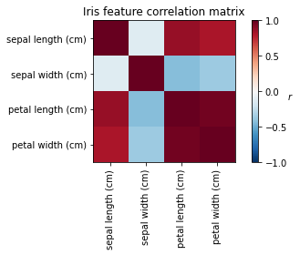

```python
ax = plt.axes()
im = ax.imshow(np.corrcoef(X.T), cmap="RdBu_r", vmin=-1, vmax=1)
ax.set_xticks([0, 1, 2, 3])
ax.set_xticklabels(list(feature_names), rotation=90)
ax.set_yticks([0, 1, 2, 3])
ax.set_yticklabels(list(feature_names))
plt.colorbar(im).ax.set_ylabel("$r$", rotation=0)
ax.set_title("Iris feature correlation matrix")
plt.tight_layout()
```

### [Independent Component Analysis (ICA)](https://scikit-learn.org/stable/modules/generated/sklearn.decomposition.FastICA.html#sklearn.decomposition.FastICA)

- ICA separates multivariate signals into *maximally indepedent subcomponents*.
- ICA does not include a noise term, so *whitening* must be applied for correct modeling. This can be done internally or with a PCA variant.